# GeneBodyPlot and VennPlot

Dr.Parul Kulshreshtha

```r
# Load required libraries
library(ChIPseeker)
library(TxDb.Hsapiens.UCSC.hg19.knownGene)
library(GenomicRanges)

# Define TxDb object
txdb <- TxDb.Hsapiens.UCSC.hg19.knownGene
```

What is GRanges?

A special data structure from the GenomicRanges Bioconductor package Stores genomic coordinates (chromosome, start, end, strand) efficiently Standard format for representing peaks, genes, or any genomic intervals in R

Why we use it:

ChIPseeker, and most Bioconductor tools, require peaks in GRanges format Allows efficient operations like finding overlaps, sorting by position, subsetting Keeps all peak information (position + metadata like score, p-value) together

So peak_GR = “peak GRanges object” - your peaks stored in this genomic coordinate format that ChIPseeker can work with.

```r
# Define BED files with full paths
peak_files <- list(
  "Control.FOXA1" = "~/CHIP_Analysis/GSM1919987_CFPAC1.wtKLF5_FOXA1_vs_INPUT.CAPAN1_peaks.bed",
  "KLF5-KO.FOXA1" = "~/CHIP_Analysis/GSM1919985_CFPAC1.crKLF5_FOXA1_vs_INPUT.CAPAN1_peaks.bed",
  "Control.ELF3"  = "~/CHIP_Analysis/GSM1919986_CFPAC1.wtKLF5.ELF3_vs_INPUT.CAPAN1_peaks.bed",
  "KLF5-KO.ELF3"  = "~/CHIP_Analysis/GSM1919984_CFPAC1.crKLF5.ELF3_vs_INPUT.CAPAN1_peaks.bed"
)

# Verify files exist
sapply(peak_files, file.exists)
```

```
## Control.FOXA1 KLF5-KO.FOXA1  Control.ELF3  KLF5-KO.ELF3
##          TRUE          TRUE          TRUE          TRUE
```

```r
# Read BED files into GRanges
peak_GR <- lapply(peak_files, readPeakFile)

# Verify successful loading
names(peak_GR)
```

```
## [1] "Control.FOXA1" "KLF5-KO.FOXA1" "Control.ELF3"  "KLF5-KO.ELF3"
```

A gene body plot (also called a metagene plot or average gene profile) is a fundamental visualization in genomics that shows the distribution of a signal across a standardized gene structure. Here’s why it’s important and widely studied: Why Gene Body Plots Matter 1. Reveals Functional Patterns Gene body plots show how signals like histone marks, transcription factors, or RNA polymerase are distributed from the transcription start site (TSS) through the gene body to the transcription end site (TES). This reveals mechanistic insights—for example, H3K36me3 enrichment in gene bodies indicates active transcription, while H3K4me3 peaks at promoters. 2. Quality Control for ChIP-seq/ATAC-seq They’re essential QC metrics. A good ChIP-seq experiment for an active mark should show expected patterns (e.g., H3K27ac at TSS, elongating Pol II through gene body). Unexpected patterns immediately flag technical problems. 3. Comparative Analysis You can overlay multiple conditions (like your FOXA1 ChIP-seq in control vs KLF5-KO cells) to see how binding patterns change. Shifts in peak position or intensity reveal biological differences in transcriptional regulation. 4. Normalize for Gene Length By scaling all genes to the same length, you can aggregate thousands of genes to see consensus patterns. This addresses the challenge that genes vary from <1kb to >1Mb in length. 5. Identify Co-regulatory Mechanisms Comparing different factors (like FOXA1 vs ELF3 in your project) reveals whether they bind similarly or have distinct spatial preferences, suggesting cooperative vs independent mechanisms.

[output not shown]

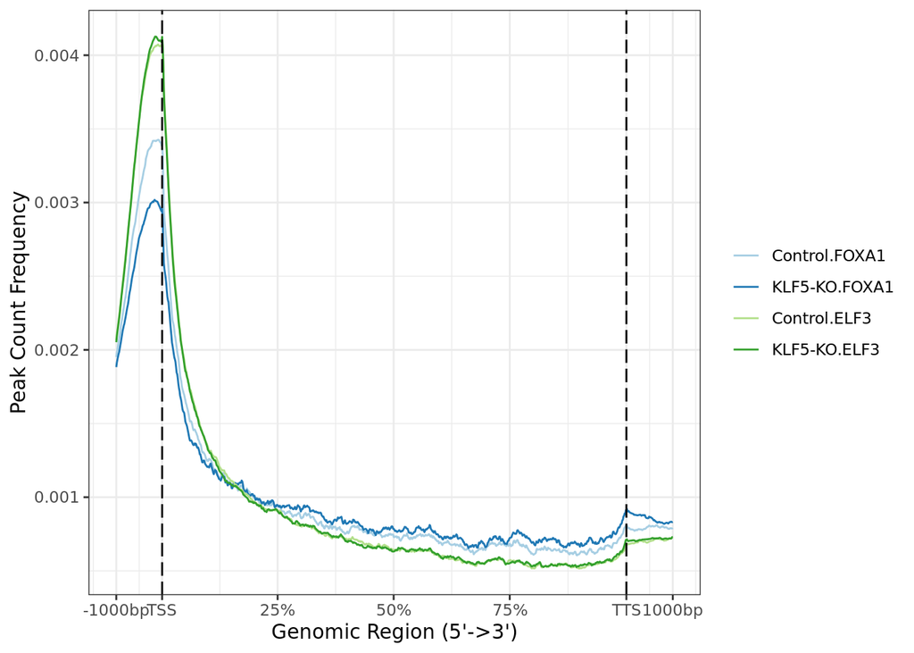

```r
# gene-body plot
plotPeakProf2(
  peak_GR,
  upstream = 1000,
  downstream = 1000,
  by = "gene",
  type = "body",
  TxDb = txdb,
  nbin = 800
)
```

Importance of Venn Diagrams in ChIP-seq Analysis Venn plots are crucial visualization tools in genomics that reveal the biological relationships between different experimental conditions or factors.

```r
library(ChIPseeker)
library(TxDb.Hsapiens.UCSC.hg19.knownGene)
txdb <- TxDb.Hsapiens.UCSC.hg19.knownGene

# Peak files split by TF with full paths
foxa1_files <- list(
  "Control.FOXA1" = "~/CHIP_Analysis/GSM1919987_CFPAC1.wtKLF5_FOXA1_vs_INPUT.CAPAN1_peaks.bed",
  "KLF5-KO.FOXA1" = "~/CHIP_Analysis/GSM1919985_CFPAC1.crKLF5_FOXA1_vs_INPUT.CAPAN1_peaks.bed"
)

elf3_files <- list(
  "Control.ELF3"  = "~/CHIP_Analysis/GSM1919986_CFPAC1.wtKLF5.ELF3_vs_INPUT.CAPAN1_peaks.bed",
  "KLF5-KO.ELF3"  = "~/CHIP_Analysis/GSM1919984_CFPAC1.crKLF5.ELF3_vs_INPUT.CAPAN1_peaks.bed"
)

# Verify files exist before proceeding
cat("Checking FOXA1 files:\n")
```

```
## Checking FOXA1 files:
```

```r
sapply(foxa1_files, file.exists)
```

```
## Control.FOXA1 KLF5-KO.FOXA1
##          TRUE          TRUE
```

```r
cat("\nChecking ELF3 files:\n")
```

```
##
## Checking ELF3 files:
```

```r
sapply(elf3_files, file.exists)
```

```
## Control.ELF3 KLF5-KO.ELF3
##         TRUE         TRUE
```

[output not shown]

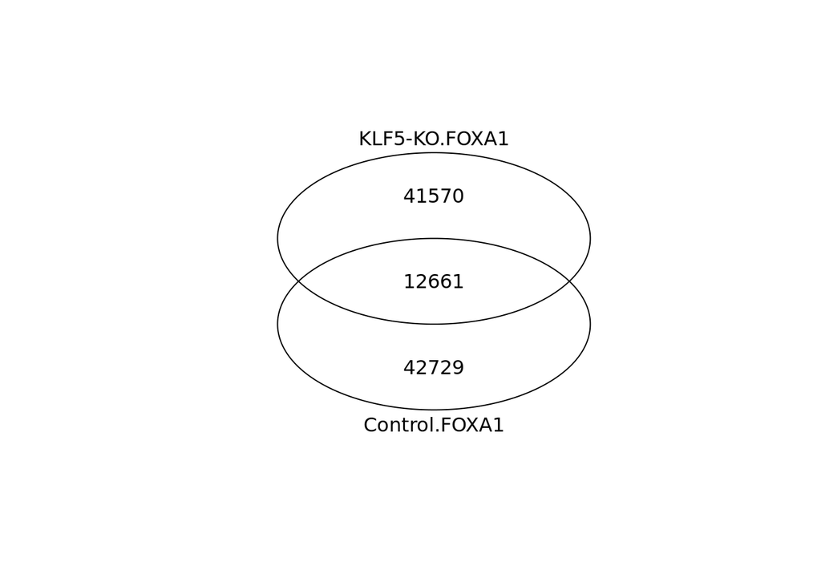

```r
# Function to generate Venn for a pair of files
plotVenn <- function(files, tf_name){
  peaks <- lapply(files, readPeakFile)
  peakAnno <- lapply(peaks, function(p) annotatePeak(p, TxDb=txdb, tssRegion=c(-3000, 3000), verbose=FALSE))
  genes <- lapply(peakAnno, function(i) as.data.frame(i)$geneId)
  vennplot(genes, main = paste("Overlap of Annotated Genes -", tf_name))
}

# Generate Venn diagrams
# 1. FOXA1
plotVenn(foxa1_files, "FOXA1")
```

[output not shown]

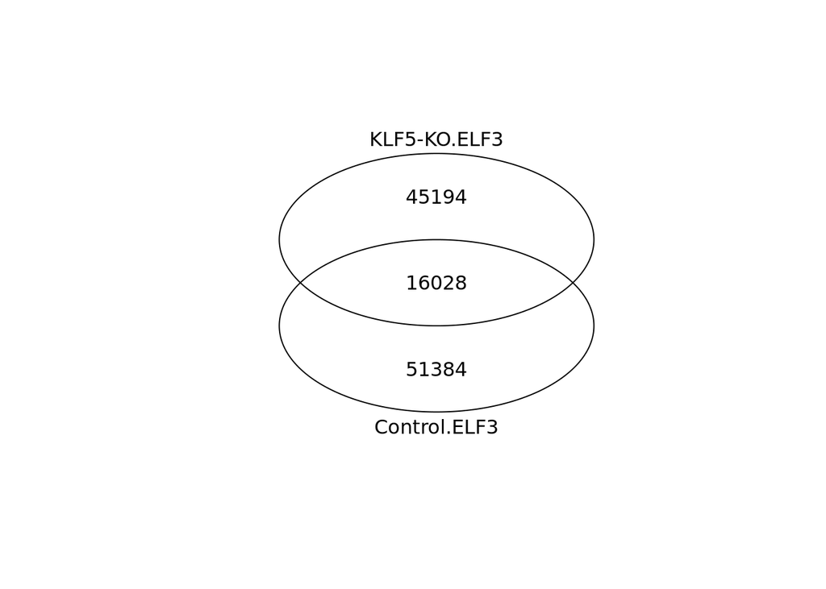

```r
# 2. ELF3
plotVenn(elf3_files, "ELF3")
```